# Case Study 3: Galeries Lafayette

UNIGE - GSEM - Advanced Data-Driven Decision Making

2023-04-18

Abstract

Identify the key drivers of brand equity for Galeries Lafayette based on a questionnaire mailed to 5000 customers and returned by 600 of them

> *This analysis was prepared by Francisco Arrieta and Jonathan Edwards.*

## 0.1 Setup

```r
# options(scipen=999) #prevent scientific notation
# options(scipen=-999) #encourage scientific notation
options(scipen=0) #encourage scientific notation neutral?
```

## 0.2 load data

```r
# modelling
library(psych) #factor analysis tools (PCA PAF)
library(lavaan) #causal analysis
library(lm.beta) # add standarized regression coeffs

# stats
library(nortest) #Kolmogorov-Smirnov-Test
library(corrplot) #correlation matrix plot
library(olsrr)  #VIF and Tolerance Values
library(pastecs) # provides function stat.desc
library(REdaS) #Bartelett's Test

# plotting & formatting
library(ggplot2) #better graphs
library(patchwork) # provides wrap_plots for multiplotting
# library(gridExtra) #provides multiplotting functionality
# library(ggpubr) #provides ggarrange for multiplotting (patchwork better though)
library(semPlot) #for visualization of path diagrams (SEM)
library(lavaanPlot) #for visualization of path diagrams (SEM)
# library(rcompanion)   #Histogram and Normal Curve
library(kableExtra) #makes nice tables

# generic
library(dplyr) #useful data manip functions like arrange, distinct, rename etc included in fpp3
library(stringr) # provides string manip functions like str_split_fixed
library(Hmisc) #describe function that describes features of dataframes
library(data.table) # creating and manipulating datatables
library(knitr) #rmarkdown tools not sure why useful
library(parameters) #get model outputs in table form (good for making tabs)
```

## 0.3 Load data

```r
survey <- read.csv("Case Study III_Structural Equation Modeling.csv")
labels <- read.csv("Variables and Labels_Galeries Lafayette.csv")

survey
```

```
##     Im1 Im2 Im3 Im4 Im5 Im6 Im7 Im8 Im9 Im10 Im11 Im12 Im13 Im14 Im15 Im16 Im17
## 1     7   7   4   4   4   7 999 999   6    7    7    6    4    7    5    5    4
## 2     4   4 999   4   3   5   3   5   4    5    4    5    5    5    4    4    4
## 3     5   5   7   7   7   4 999   6   6    7    7    7    7    7    6    6    6
## 4     5   5   5   5   5   4   4   4   4    4    6    6    6    5    6    5    4
## 5     4   4   4   3   5   4   4   4   3    6    5    4    4    6    4    3    3
## 6     4   4   5   5 999   4   2   5   3    3    5    3    3  999    3    3    5
## 7     4   5   6   6   6   7   7   6   7    5    5    6    6    6    4    3    5
## 8     7   7   4   4   4   6   7   6   4    6    5    7    6    6    5    4    3
## 9     4   4   4   4   5   5   5   5   5    6    6    6    6    6    5    5    5
## 10    4   4   3   3   4   5   5   4   5    4    5    4    5    4    4    4    5
## 11  999 999   4   5   5   5   5   6   5    6    6    6    6    6    6    6    4
## 12    4   4   7   7   7   7   7   7   6    7    6    6    6    7    6    5    6
## 13    6 999   6   6   6   6   6   6   6    6    6    6    6    6    6    6    6
## 14    6   6   4   4   6   4   4   5   5    4    6    6    6    5    5    4    5
```

[output cut: 2201 more lines]

## 0.4 Clean and handle missing data

```r
# # omit all unanswered
# filter_all(survey, all_vars(. != 999))
# filter_all(survey, any_vars(. %in% c(999)))
#
# filter_all(select(survey,1:22,"SAT_1"), all_vars(. != 999))
# filter_all(select(survey,1:22,"SAT_1"), any_vars(. %in% c(999)))
#
# filter_all(data_EFA, all_vars(. != 999))
# filter_all(ges, any_vars(. %in% c(999)))
```

```r
# delete variables unused in analysis (see case study instructions):
survey <- survey |> select(-c("C_CR2", "SAT_P1", "SAT_P2", "SAT_P3", "SAT_P4", "SAT_P5", "SAT_P6", "TRU_1", "TRU_2", "TRU_3"))

# replace missing data (999) with NA
survey <- data.frame(sapply(survey,function(x) ifelse((x==999),NA,as.numeric(x))))

# delete missing data
survey <- na.omit(survey)
survey
```

```
##     Im1 Im2 Im3 Im4 Im5 Im6 Im7 Im8 Im9 Im10 Im11 Im12 Im13 Im14 Im15 Im16 Im17
## 7     4   5   6   6   6   7   7   6   7    5    5    6    6    6    4    3    5
## 8     7   7   4   4   4   6   7   6   4    6    5    7    6    6    5    4    3
## 14    6   6   4   4   6   4   4   5   5    4    6    6    6    5    5    4    5
## 17    6   6   6   5   5   7   6   6   6    6    6    6    5    7    5    6    4
## 33    6   6   7   7   6   4   4   6   6    6    5    5    5    6    7    7    6
## 35    6   6   7   7   7   7   7   7   7    7    7    7    7    7    6    7    7
## 38    4   4   4   4   3   6   6   6   5    6    6    6    5    5    6    6    5
## 40    3   3   1   1   5   2   4   7   5    7    3    6    2    5    6    6    1
## 41    4   5   7   7   6   7   7   7   6    7    5    7    7    7    6    6    7
## 45    5   5   4   4   5   6   6   6   6    6    6    4    6    6    4    4    5
## 46    5   5   4   4   1   5   5   5   1    5    1    1    1    5    5    5    1
## 47    5   5   5   5   5   6   6   6   6    6    6    6    6    6    5    5    5
## 48    4   4   4   4   4   6   5   5   5    6    6    6    6    6    6    6    6
## 49    6   6   6   6   5   5   5   6   3    6    6    6    6    6    6    6    6
```

[output cut: 915 more lines]

## 0.5 Explore Data

# 1 Dimensions by which Galeries Lafayette is perceived

## 1.1 Variable selection

```r
data_EFA <- survey[1:22] #same as survey[,1:22]
data_EFA
```

```
##     Im1 Im2 Im3 Im4 Im5 Im6 Im7 Im8 Im9 Im10 Im11 Im12 Im13 Im14 Im15 Im16 Im17
## 7     4   5   6   6   6   7   7   6   7    5    5    6    6    6    4    3    5
## 8     7   7   4   4   4   6   7   6   4    6    5    7    6    6    5    4    3
## 14    6   6   4   4   6   4   4   5   5    4    6    6    6    5    5    4    5
## 17    6   6   6   5   5   7   6   6   6    6    6    6    5    7    5    6    4
## 33    6   6   7   7   6   4   4   6   6    6    5    5    5    6    7    7    6
## 35    6   6   7   7   7   7   7   7   7    7    7    7    7    7    6    7    7
## 38    4   4   4   4   3   6   6   6   5    6    6    6    5    5    6    6    5
## 40    3   3   1   1   5   2   4   7   5    7    3    6    2    5    6    6    1
## 41    4   5   7   7   6   7   7   7   6    7    5    7    7    7    6    6    7
## 45    5   5   4   4   5   6   6   6   6    6    6    4    6    6    4    4    5
## 46    5   5   4   4   1   5   5   5   1    5    1    1    1    5    5    5    1
## 47    5   5   5   5   5   6   6   6   6    6    6    6    6    6    5    5    5
## 48    4   4   4   4   4   6   5   5   5    6    6    6    6    6    6    6    6
## 49    6   6   6   6   5   5   5   6   3    6    6    6    6    6    6    6    6
```

[output cut: 605 more lines]

## 1.2 Exploratory factor analysis

### 1.2.1 Check adequacy of correlation Matrix

#### 1.2.1.1 correlation matrix

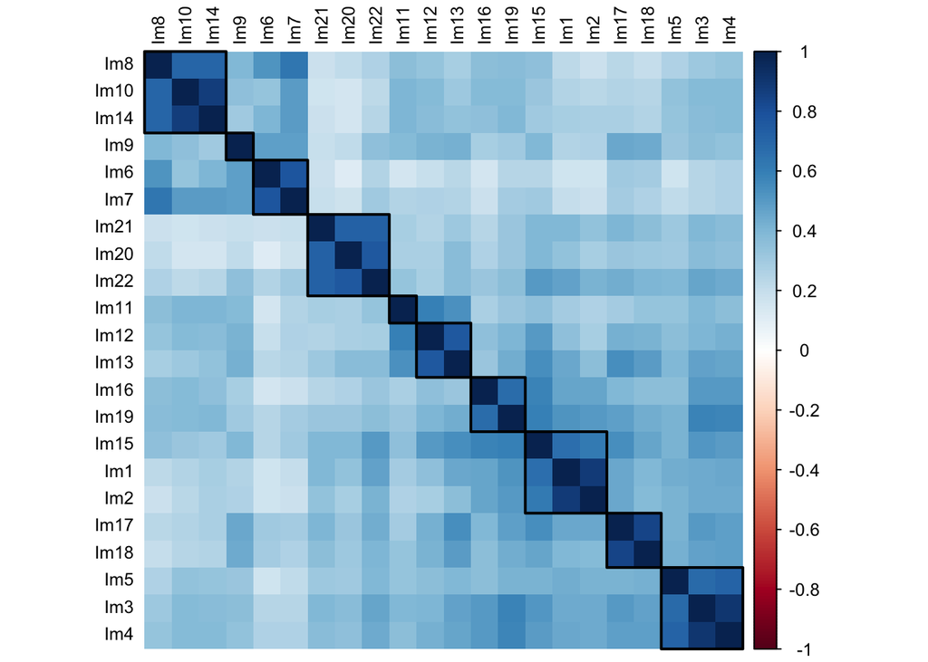

```r
#plot correlation matrix adjusting parameters to see previously identified groupings
corr_matrix <- cor(data_EFA)
corrplot(as.matrix(corr_matrix),
         method = "shade",
         order = "hclust",
         addrect = 10,
         tl.col ="black",
         tl.cex = 0.80)
```

#### 1.2.1.2 Bartlett’s Test

```r
bart_spher(data_EFA)
```

```
##  Bartlett's Test of Sphericity
##
## Call: bart_spher(x = data_EFA)
##
##      X2 = 5268.134
##      df = 231
## p-value < 2.22e-16
```

The Bartlett Test tests the hypothesis that the sample originates from a population, where all variables are uncorrelated. This would not be good for factor analysis, we want this hypothesis to be rejected meaning p-value < 5%.

In our case we see that it is indeed rejected and that the data is not uncorrelated.

#### 1.2.1.3 KMO

```r
KMOTEST=KMOS(data_EFA)
print(KMOTEST, sort=T)
```

```
##
## Kaiser-Meyer-Olkin Statistics
##
## Call: KMOS(x = data_EFA)
##
## Measures of Sampling Adequacy (MSA):
##       Im6      Im10      Im14       Im2       Im1       Im7      Im20      Im17
## 0.7791619 0.8192843 0.8206186 0.8275596 0.8316756 0.8342908 0.8369658 0.8459668
##      Im18       Im4       Im3      Im13      Im12      Im22      Im21      Im11
## 0.8479170 0.8623498 0.8647696 0.8749019 0.8763560 0.8850423 0.8930068 0.9101259
##      Im16       Im8       Im9      Im19      Im15       Im5
## 0.9168866 0.9231784 0.9240378 0.9432565 0.9558911 0.9616355
##
## KMO-Criterion: 0.8739058
```

The KMO of 0.8739058 is above 0.6 which indicates the data is well suited for factor anlysis.

#### 1.2.1.4 Anti-image Correlation

```r
MSA_list <- data.table("Item"=names(KMOTEST$MSA), "MSA"=as.numeric(KMOTEST$MSA))

#Highlighted items that are less than the total KMO value. However many are below this value.
#None are lower than the 0.5 threshold that is indicated in the slides
#Display table
MSA_list<- MSA_list |>
  setorder(cols = "MSA")

MSA_list |>
  kable() |>
  kable_minimal() |>
  row_spec(which(MSA_list[,2]<KMOTEST$KMO), bold = T, color = "white", background = "#78BE20")
```

| Item | MSA |
| --- | --- |
| Im6 | 0.7791619 |
| Im10 | 0.8192843 |
| Im14 | 0.8206186 |
| Im2 | 0.8275596 |
| Im1 | 0.8316756 |
| Im7 | 0.8342908 |
| Im20 | 0.8369658 |
| Im17 | 0.8459668 |
| Im18 | 0.8479170 |
| Im4 | 0.8623498 |
| Im3 | 0.8647696 |
| Im13 | 0.8749019 |
| Im12 | 0.8763560 |
| Im22 | 0.8850423 |
| Im21 | 0.8930068 |
| Im11 | 0.9101259 |
| Im16 | 0.9168866 |
| Im8 | 0.9231784 |
| Im9 | 0.9240378 |
| Im19 | 0.9432565 |
| Im15 | 0.9558911 |
| Im5 | 0.9616355 |

Variables with MSA values above 0.5 are suited for factor analysis. Presence of items with low MSA’s (<0.5) could also indicate that an important topic hasn’t been well covered in the questionnaire.

All variables have MSA above 0.5

### 1.2.2 PCA

#### 1.2.2.1 Extract factors

```r
EFA_PC0 <- psych::principal(data_EFA, rotate="varimax", scores=TRUE)
```

##### 1.2.2.1.1 Scree plot

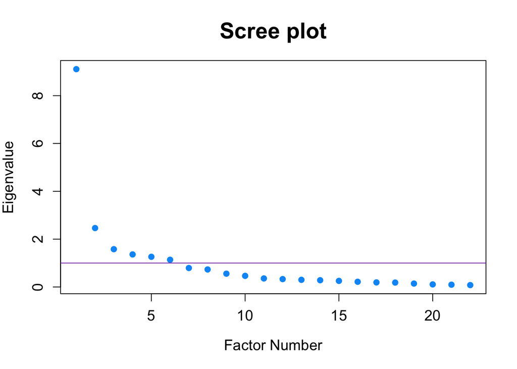

```r
#display Scree-plot
plot(EFA_PC0$values,xlab="Factor Number",
     ylab="Eigenvalue",
     main="Scree plot",
     cex.lab=1.2,
     cex.axis=1.2,
     cex.main=1.8,
     col = "#0099F8",
     pch = 19)
abline(h=1, col = "#7F35B2")
```

##### 1.2.2.1.2 Kaiser Criterion

```r
EFA_PC0_kaiser_nb <- length(which(EFA_PC0$values > 1))
EFA_PC0_kaiser_nb
```

```
## [1] 6
```

The Kaiser criterion suggests we should retain factors with eigenvalues bigger than 1.

There are 6 satisfying this condition.

##### 1.2.2.1.3 Total Variance Explained

```r
#calculate total variance using PAF with nfators = 5
EFA_PC0_EigenValue <- EFA_PC0$values
EFA_PC0_Variance <- EFA_PC0_EigenValue / ncol(data_EFA) * 100
EFA_PC0_SumVariance <- cumsum(EFA_PC0_EigenValue / ncol(data_EFA))
EFA_PC0_Total_Variance_Explained <- cbind("Factor number"=
                                            seq(1, length.out=length(EFA_PC0_EigenValue[EFA_PC0_EigenValue>0])),
                                          EigenValue = EFA_PC0_EigenValue[EFA_PC0_EigenValue>0],
                                          Variance = EFA_PC0_Variance[EFA_PC0_EigenValue>0],
                                          Total_Variance = EFA_PC0_SumVariance[EFA_PC0_EigenValue>0])
#display table
EFA_PC0_Total_Variance_Explained |>
  kable() |>
  kable_minimal()
```

| Factor number | EigenValue | Variance | Total_Variance |
| --- | --- | --- | --- |
| 1 | 9.1082994 | 41.4013607 | 0.4140136 |
| 2 | 2.4636132 | 11.1982419 | 0.5259960 |
| 3 | 1.5798945 | 7.1813386 | 0.5978094 |
| 4 | 1.3609873 | 6.1863059 | 0.6596725 |
| 5 | 1.2616704 | 5.7348656 | 0.7170211 |
| 6 | 1.1384724 | 5.1748747 | 0.7687699 |
| 7 | 0.7928855 | 3.6040249 | 0.8048101 |
| 8 | 0.7323560 | 3.3288907 | 0.8380990 |
| 9 | 0.5562405 | 2.5283660 | 0.8633827 |
| 10 | 0.4649283 | 2.1133107 | 0.8845158 |
| 11 | 0.3568648 | 1.6221127 | 0.9007369 |
| 12 | 0.3291269 | 1.4960313 | 0.9156972 |
| 13 | 0.2991844 | 1.3599293 | 0.9292965 |
| 14 | 0.2826208 | 1.2846401 | 0.9421429 |
| 15 | 0.2546297 | 1.1574079 | 0.9537170 |
| 16 | 0.2176802 | 0.9894553 | 0.9636116 |
| 17 | 0.1912401 | 0.8692733 | 0.9723043 |
| 18 | 0.1843325 | 0.8378749 | 0.9806830 |
| 19 | 0.1429331 | 0.6496960 | 0.9871800 |
| 20 | 0.1078292 | 0.4901326 | 0.9920813 |
| 21 | 0.0953037 | 0.4331985 | 0.9964133 |
| 22 | 0.0789070 | 0.3586683 | 1.0000000 |

With 6 factors we would explain 76.8769874% of total variance.

With 7 factors we would explain 80.4810123% of total variance.

```r
# test eigenvalue calculation
factorloadings = EFA_PC0$loadings[,1] # loadings 1st factor (default is nfactors = 1)
Eigenvalue = sum(factorloadings^2)
Eigenvalue
```

```
## [1] 9.108299
```

[output not shown]

#### 1.2.2.2 Select number of factors to test

```r
# select nb of factors to test
nf = c(5,6,7,8)
```

#### 1.2.2.3 PCA orthogonal Varimax with n factors

```r
# perform PCA orthogonal for different numbers of factors
EFA_PCn = list()

i=1
for (n in nf) {
  # EFA_PCn[[i]] <- n
  EFA_PCn[[i]] <- psych::principal(data_EFA, rotate="varimax", scores=TRUE, nfactors = n)
  i=i+1
}
names(EFA_PCn) <- nf

length(EFA_PCn)
```

```
## [1] 4
```

##### 1.2.2.3.1 Communalities

```r
#communalities for all selected number of factors

for (i in 1:length(nf)) {

  cat("###### Number of factors =", nf[[i]], "{.unnumbered}" ,"\n")

    EFA_PCn_communalities <- data.frame(sort(EFA_PCn[[i]]$communality))
    kbl <- EFA_PCn_communalities |>
              kable() |>
              kable_minimal() |>
              row_spec(which(EFA_PCn_communalities[,1]<.3), bold = T, color = "white", background = "#78BE20")

    print(kbl)
    cat("\n\n")

    # test communality calculation
    variableloading = EFA_PCn[[i]]$loadings["Im9",] # loadings 1st variable
    communality = sum(variableloading^2)
    print(paste0("Communality for Im9 =", communality))
    cat("\n")

}
```

###### Number of factors = 5

|  | sort.EFA_PCn..i…communality. |
| --- | --- |
| Im5 | 0.5014170 |
| Im16 | 0.5939443 |
| Im9 | 0.5940178 |
| Im19 | 0.6323500 |
| Im11 | 0.6367797 |
| Im15 | 0.6472754 |
| Im4 | 0.6502482 |
| Im3 | 0.6575263 |
| Im18 | 0.7006291 |
| Im1 | 0.7021509 |
| Im2 | 0.7112292 |
| Im13 | 0.7429606 |
| Im17 | 0.7490344 |
| Im12 | 0.7572378 |
| Im8 | 0.7850519 |
| Im6 | 0.7907473 |
| Im14 | 0.7988625 |
| Im21 | 0.8068684 |
| Im7 | 0.8155173 |
| Im10 | 0.8171880 |
| Im20 | 0.8392852 |
| Im22 | 0.8441436 |

[1] “Communality for Im9 =0.594017816795484”

###### Number of factors = 6

|  | sort.EFA_PCn..i…communality. |
| --- | --- |
| Im9 | 0.5958911 |
| Im16 | 0.5995686 |
| Im19 | 0.6333999 |
| Im11 | 0.6711879 |
| Im5 | 0.6954890 |
| Im15 | 0.7222814 |
| Im18 | 0.7284000 |
| Im17 | 0.7600763 |
| Im13 | 0.7822314 |
| Im8 | 0.7902322 |
| Im6 | 0.8008731 |
| Im14 | 0.8025119 |
| Im21 | 0.8069967 |
| Im2 | 0.8109214 |
| Im12 | 0.8120365 |
| Im7 | 0.8156398 |
| Im10 | 0.8188860 |
| Im1 | 0.8324019 |
| Im20 | 0.8405791 |
| Im22 | 0.8443770 |
| Im3 | 0.8688830 |
| Im4 | 0.8800732 |

[1] “Communality for Im9 =0.595891095205667”

###### Number of factors = 7

|  | sort.EFA_PCn..i…communality. |
| --- | --- |
| Im9 | 0.6153673 |
| Im11 | 0.6954386 |
| Im19 | 0.7110636 |
| Im15 | 0.7232322 |
| Im16 | 0.7355642 |
| Im5 | 0.7822739 |
| Im13 | 0.7866611 |
| Im8 | 0.7974248 |
| Im14 | 0.8102111 |
| Im21 | 0.8115554 |
| Im12 | 0.8140388 |
| Im18 | 0.8156443 |
| Im6 | 0.8223779 |
| Im10 | 0.8327821 |
| Im7 | 0.8337149 |
| Im17 | 0.8439687 |
| Im22 | 0.8446924 |
| Im20 | 0.8531328 |
| Im3 | 0.8783527 |
| Im2 | 0.8920204 |
| Im4 | 0.8958577 |
| Im1 | 0.9104475 |

[1] “Communality for Im9 =0.61536730713009”

###### Number of factors = 8

|  | sort.EFA_PCn..i…communality. |
| --- | --- |
| Im9 | 0.6474321 |
| Im11 | 0.6956795 |
| Im15 | 0.7524440 |
| Im19 | 0.7760559 |
| Im13 | 0.7897235 |
| Im5 | 0.7965617 |
| Im8 | 0.7977129 |
| Im21 | 0.8173321 |
| Im12 | 0.8325098 |
| Im16 | 0.8396510 |
| Im22 | 0.8447200 |
| Im7 | 0.8452234 |
| Im6 | 0.8479345 |
| Im20 | 0.8576186 |
| Im3 | 0.8903200 |
| Im10 | 0.8994713 |
| Im4 | 0.9044748 |
| Im14 | 0.9075025 |
| Im18 | 0.9153894 |
| Im17 | 0.9212801 |
| Im2 | 0.9247103 |
| Im1 | 0.9344310 |

[1] “Communality for Im9 =0.647432149693193”

##### 1.2.2.3.2 Factor loadings

```r
# loadings for all selected number of factors

test = list()

for (i in 1:length(nf)) {

cat("###### Number of factors =", nf[[i]], "{.unnumbered}" ,"\n")

      # print(EFA_PCn[[i]]$loadings, cutoff=0.3)
      print(print_html(model_parameters(EFA_PCn[[i]], loadings=T, threshold = 0.3, summary=T)))

cat("\n\n")
}
```

###### Number of factors = 5

| Variable | RC1 | RC2 | RC4 | RC3 | RC5 | Complexity | Uniqueness |
| --- | --- | --- | --- | --- | --- | --- | --- |
| Im1 | 0.79 |  |  |  |  | 1.24 | 0.30 |
| Im2 | 0.82 |  |  |  |  | 1.14 | 0.29 |
| Im3 | 0.64 |  | 0.36 |  |  | 2.25 | 0.34 |
| Im4 | 0.65 |  | 0.35 |  |  | 2.16 | 0.35 |
| Im5 | 0.56 |  | 0.34 |  |  | 2.26 | 0.50 |
| Im6 |  | 0.37 |  |  | 0.80 | 1.46 | 0.21 |
| Im7 |  | 0.52 |  |  | 0.72 | 1.92 | 0.18 |
| Im8 |  | 0.79 |  |  | 0.34 | 1.53 | 0.21 |
| Im9 |  |  | 0.41 |  | 0.60 | 2.19 | 0.41 |
| Im10 |  | 0.84 |  |  |  | 1.35 | 0.18 |
| Im11 |  | 0.33 | 0.69 |  |  | 1.68 | 0.36 |
| Im12 |  |  | 0.81 |  |  | 1.35 | 0.24 |
| Im13 | 0.31 |  | 0.76 |  |  | 1.61 | 0.26 |
| Im14 |  | 0.82 |  |  |  | 1.38 | 0.20 |
| Im15 | 0.68 |  |  |  |  | 1.90 | 0.35 |
| Im16 | 0.71 |  |  |  |  | 1.36 | 0.41 |
| Im17 | 0.51 |  | 0.44 |  | 0.50 | 3.33 | 0.25 |
| Im18 | 0.45 |  | 0.47 |  | 0.48 | 3.37 | 0.30 |
| Im19 | 0.71 |  |  |  |  | 1.52 | 0.37 |
| Im20 |  |  |  | 0.88 |  | 1.18 | 0.16 |
| Im21 |  |  |  | 0.85 |  | 1.24 | 0.19 |
| Im22 | 0.31 |  |  | 0.82 |  | 1.51 | 0.16 |

###### Number of factors = 6

| Variable | RC1 | RC2 | RC6 | RC3 | RC4 | RC5 | Complexity | Uniqueness |
| --- | --- | --- | --- | --- | --- | --- | --- | --- |
| Im1 | 0.85 |  |  |  |  |  | 1.31 | 0.17 |
| Im2 | 0.86 |  |  |  |  |  | 1.20 | 0.19 |
| Im3 |  |  | 0.82 |  |  |  | 1.63 | 0.13 |
| Im4 |  |  | 0.84 |  |  |  | 1.57 | 0.12 |
| Im5 |  |  | 0.76 |  |  |  | 1.47 | 0.30 |
| Im6 |  | 0.44 |  |  |  | 0.77 | 1.66 | 0.20 |
| Im7 |  | 0.59 |  |  |  | 0.67 | 2.08 | 0.18 |
| Im8 |  | 0.82 |  |  |  |  | 1.38 | 0.21 |
| Im9 |  |  |  |  | 0.35 | 0.62 | 2.10 | 0.40 |
| Im10 |  | 0.83 |  |  |  |  | 1.38 | 0.18 |
| Im11 |  | 0.31 |  |  | 0.71 |  | 1.66 | 0.33 |
| Im12 |  |  |  |  | 0.83 |  | 1.38 | 0.19 |
| Im13 |  |  |  |  | 0.77 |  | 1.73 | 0.22 |
| Im14 |  | 0.83 |  |  |  |  | 1.38 | 0.20 |
| Im15 | 0.69 |  |  |  | 0.31 |  | 2.19 | 0.28 |
| Im16 | 0.61 |  | 0.37 |  |  |  | 2.18 | 0.40 |
| Im17 | 0.37 |  | 0.37 |  | 0.34 | 0.57 | 3.64 | 0.24 |
| Im18 |  |  | 0.40 |  | 0.36 | 0.56 | 3.50 | 0.27 |
| Im19 | 0.59 |  | 0.40 |  |  |  | 2.58 | 0.37 |
| Im20 |  |  |  | 0.88 |  |  | 1.20 | 0.16 |
| Im21 |  |  |  | 0.85 |  |  | 1.25 | 0.19 |
| Im22 |  |  |  | 0.82 |  |  | 1.52 | 0.16 |

###### Number of factors = 7

| Variable | RC2 | RC1 | RC3 | RC6 | RC4 | RC5 | RC7 | Complexity | Uniqueness |
| --- | --- | --- | --- | --- | --- | --- | --- | --- | --- |
| Im1 |  | 0.88 |  |  |  |  |  | 1.39 | 0.09 |
| Im2 |  | 0.89 |  |  |  |  |  | 1.28 | 0.11 |
| Im3 |  |  |  | 0.80 |  |  |  | 1.82 | 0.12 |
| Im4 |  |  |  | 0.82 |  |  |  | 1.71 | 0.10 |
| Im5 |  |  |  | 0.81 |  |  |  | 1.44 | 0.22 |
| Im6 |  |  |  |  |  | 0.86 |  | 1.24 | 0.18 |
| Im7 | 0.39 |  |  |  |  | 0.81 |  | 1.55 | 0.17 |
| Im8 | 0.76 |  |  |  |  | 0.42 |  | 1.75 | 0.20 |
| Im9 |  |  |  |  | 0.38 | 0.59 |  | 2.55 | 0.38 |
| Im10 | 0.83 |  |  |  |  |  |  | 1.41 | 0.17 |
| Im11 |  |  |  |  | 0.74 |  |  | 1.56 | 0.30 |
| Im12 |  |  |  |  | 0.82 |  |  | 1.46 | 0.19 |
| Im13 |  |  |  |  | 0.75 |  |  | 1.85 | 0.21 |
| Im14 | 0.81 |  |  |  |  |  |  | 1.48 | 0.19 |
| Im15 |  | 0.61 |  |  |  |  | 0.36 | 3.08 | 0.28 |
| Im16 | 0.49 | 0.43 |  |  |  |  | 0.49 | 3.64 | 0.26 |
| Im17 |  |  |  |  |  |  | 0.76 | 2.00 | 0.16 |
| Im18 |  |  |  |  |  |  | 0.76 | 1.92 | 0.18 |
| Im19 | 0.43 | 0.43 |  |  |  |  | 0.48 | 3.89 | 0.29 |
| Im20 |  |  | 0.89 |  |  |  |  | 1.17 | 0.15 |
| Im21 |  |  | 0.85 |  |  |  |  | 1.23 | 0.19 |
| Im22 |  |  | 0.82 |  |  |  |  | 1.55 | 0.16 |

###### Number of factors = 8

| Variable | RC3 | RC2 | RC4 | RC6 | RC5 | RC7 | RC1 | RC8 | Complexity | Uniqueness |
| --- | --- | --- | --- | --- | --- | --- | --- | --- | --- | --- |
| Im1 |  |  |  |  |  | 0.87 |  |  | 1.53 | 0.07 |
| Im2 |  |  |  |  |  | 0.88 |  |  | 1.40 | 0.08 |
| Im3 |  |  |  | 0.80 |  |  | 0.31 |  | 1.89 | 0.11 |
| Im4 |  |  |  | 0.82 |  |  |  |  | 1.77 | 0.10 |
| Im5 |  |  |  | 0.80 |  |  |  |  | 1.54 | 0.20 |
| Im6 |  |  |  |  | 0.88 |  |  |  | 1.17 | 0.15 |
| Im7 |  | 0.37 |  |  | 0.83 |  |  |  | 1.48 | 0.15 |
| Im8 |  | 0.70 |  |  | 0.46 |  |  |  | 2.18 | 0.20 |
| Im9 |  |  | 0.40 |  | 0.62 |  |  |  | 2.42 | 0.35 |
| Im10 |  | 0.88 |  |  |  |  |  |  | 1.34 | 0.10 |
| Im11 |  |  | 0.73 |  |  |  |  |  | 1.61 | 0.30 |
| Im12 |  |  | 0.84 |  |  |  |  |  | 1.39 | 0.17 |
| Im13 |  |  | 0.76 |  |  |  |  |  | 1.83 | 0.21 |
| Im14 |  | 0.89 |  |  |  |  |  |  | 1.33 | 0.09 |
| Im15 |  |  | 0.33 |  |  | 0.49 | 0.50 |  | 4.16 | 0.25 |
| Im16 |  |  |  |  |  |  | 0.82 |  | 1.53 | 0.16 |
| Im17 |  |  |  |  |  |  |  | 0.83 | 1.77 | 0.08 |
| Im18 |  |  |  |  |  |  |  | 0.85 | 1.57 | 0.08 |
| Im19 |  |  |  |  |  |  | 0.71 |  | 2.21 | 0.22 |
| Im20 | 0.89 |  |  |  |  |  |  |  | 1.18 | 0.14 |
| Im21 | 0.85 |  |  |  |  |  |  |  | 1.25 | 0.18 |
| Im22 | 0.82 |  |  |  |  |  |  |  | 1.55 | 0.16 |

#### 1.2.2.4 PCA oblique Promax with n factors

```r
# perform PCA oblique for different numbers of factors
EFA_PCn_obl = list()

i=1
for (n in nf) {
  # EFA_PCn_obl[[i]] <- n
  EFA_PCn_obl[[i]] <- psych::principal(data_EFA, rotate="promax", scores=TRUE, nfactors = n)
  i=i+1
}
names(EFA_PCn_obl) <- nf

length(EFA_PCn_obl)
```

```
## [1] 4
```

##### 1.2.2.4.1 Communalities

```r
#communalities for all selected number of factors

for (i in 1:length(nf)) {

  cat("###### Number of factors =", nf[[i]], "{.unnumbered}" ,"\n")

    EFA_PCn_obl_communalities <- data.frame(sort(EFA_PCn_obl[[i]]$communality))
    kbl <- EFA_PCn_obl_communalities |>
              kable() |>
              kable_minimal() |>
              row_spec(which(EFA_PCn_obl_communalities[,1]<.3), bold = T, color = "white", background = "#78BE20")

    print(kbl)
    cat("\n\n")

    # test communality calculation
    variableloading = EFA_PCn_obl[[i]]$loadings["Im9",] # loadings 1st variable
    communality = sum(variableloading^2)
    print(paste0("Communality for Im9 =", communality))
    cat("\n")

}
```

###### Number of factors = 5

|  | sort.EFA_PCn_obl..i…communality. |
| --- | --- |
| Im5 | 0.5014170 |
| Im16 | 0.5939443 |
| Im9 | 0.5940178 |
| Im19 | 0.6323500 |
| Im11 | 0.6367797 |
| Im15 | 0.6472754 |
| Im4 | 0.6502482 |
| Im3 | 0.6575263 |
| Im18 | 0.7006291 |
| Im1 | 0.7021509 |
| Im2 | 0.7112292 |
| Im13 | 0.7429606 |
| Im17 | 0.7490344 |
| Im12 | 0.7572378 |
| Im8 | 0.7850519 |
| Im6 | 0.7907473 |
| Im14 | 0.7988625 |
| Im21 | 0.8068684 |
| Im7 | 0.8155173 |
| Im10 | 0.8171880 |
| Im20 | 0.8392852 |
| Im22 | 0.8441436 |

[1] “Communality for Im9 =0.475662416261723”

###### Number of factors = 6

|  | sort.EFA_PCn_obl..i…communality. |
| --- | --- |
| Im9 | 0.5958911 |
| Im16 | 0.5995686 |
| Im19 | 0.6333999 |
| Im11 | 0.6711879 |
| Im5 | 0.6954890 |
| Im15 | 0.7222814 |
| Im18 | 0.7284000 |
| Im17 | 0.7600763 |
| Im13 | 0.7822314 |
| Im8 | 0.7902322 |
| Im6 | 0.8008731 |
| Im14 | 0.8025119 |
| Im21 | 0.8069967 |
| Im2 | 0.8109214 |
| Im12 | 0.8120365 |
| Im7 | 0.8156398 |
| Im10 | 0.8188860 |
| Im1 | 0.8324019 |
| Im20 | 0.8405791 |
| Im22 | 0.8443770 |
| Im3 | 0.8688830 |
| Im4 | 0.8800732 |

[1] “Communality for Im9 =0.501124010584902”

###### Number of factors = 7

|  | sort.EFA_PCn_obl..i…communality. |
| --- | --- |
| Im9 | 0.6153673 |
| Im11 | 0.6954386 |
| Im19 | 0.7110636 |
| Im15 | 0.7232322 |
| Im16 | 0.7355642 |
| Im5 | 0.7822739 |
| Im13 | 0.7866611 |
| Im8 | 0.7974248 |
| Im14 | 0.8102111 |
| Im21 | 0.8115554 |
| Im12 | 0.8140388 |
| Im18 | 0.8156443 |
| Im6 | 0.8223779 |
| Im10 | 0.8327821 |
| Im7 | 0.8337149 |
| Im17 | 0.8439687 |
| Im22 | 0.8446924 |
| Im20 | 0.8531328 |
| Im3 | 0.8783527 |
| Im2 | 0.8920204 |
| Im4 | 0.8958577 |
| Im1 | 0.9104475 |

[1] “Communality for Im9 =0.445886390654222”

###### Number of factors = 8

|  | sort.EFA_PCn_obl..i…communality. |
| --- | --- |
| Im9 | 0.6474321 |
| Im11 | 0.6956795 |
| Im15 | 0.7524440 |
| Im19 | 0.7760559 |
| Im13 | 0.7897235 |
| Im5 | 0.7965617 |
| Im8 | 0.7977129 |
| Im21 | 0.8173321 |
| Im12 | 0.8325098 |
| Im16 | 0.8396510 |
| Im22 | 0.8447200 |
| Im7 | 0.8452234 |
| Im6 | 0.8479345 |
| Im20 | 0.8576186 |
| Im3 | 0.8903200 |
| Im10 | 0.8994713 |
| Im4 | 0.9044748 |
| Im14 | 0.9075025 |
| Im18 | 0.9153894 |
| Im17 | 0.9212801 |
| Im2 | 0.9247103 |
| Im1 | 0.9344310 |

[1] “Communality for Im9 =0.604023410290431”

##### 1.2.2.4.2 Factor loadings

```r
# loadings for all selected number of factors

test = list()

for (i in 1:length(nf)) {

cat("###### Number of factors =", nf[[i]], "{.unnumbered}" ,"\n")

      # print(EFA_PCn_obl[[i]]$loadings, cutoff=0.3)
      print(print_html(model_parameters(EFA_PCn_obl[[i]], loadings=T, threshold = 0.3, summary=T)))

cat("\n\n")
}
```

###### Number of factors = 5

| Variable | RC1 | RC4 | RC2 | RC3 | RC5 | Complexity | Uniqueness |
| --- | --- | --- | --- | --- | --- | --- | --- |
| Im1 | 0.94 |  |  |  |  | 1.12 | 0.30 |
| Im2 | 1.01 |  |  |  |  | 1.18 | 0.29 |
| Im3 | 0.58 |  |  |  |  | 1.67 | 0.34 |
| Im4 | 0.60 |  |  |  |  | 1.55 | 0.35 |
| Im5 | 0.50 |  |  |  |  | 1.85 | 0.50 |
| Im6 |  |  |  |  | 0.89 | 1.32 | 0.21 |
| Im7 |  |  | 0.45 |  | 0.80 | 1.70 | 0.18 |
| Im8 |  |  | 0.75 |  | 0.36 | 1.44 | 0.21 |
| Im9 |  | 0.39 |  |  | 0.56 | 1.87 | 0.41 |
| Im10 |  |  | 0.81 |  |  | 1.12 | 0.18 |
| Im11 |  | 0.85 |  |  |  | 1.46 | 0.36 |
| Im12 |  | 0.98 |  |  |  | 1.08 | 0.24 |
| Im13 |  | 0.87 |  |  |  | 1.01 | 0.26 |
| Im14 |  |  | 0.79 |  |  | 1.13 | 0.20 |
| Im15 | 0.67 |  |  |  |  | 1.09 | 0.35 |
| Im16 | 0.83 |  |  |  |  | 1.22 | 0.41 |
| Im17 | 0.39 | 0.35 |  |  | 0.38 | 3.83 | 0.25 |
| Im18 | 0.30 | 0.42 |  |  | 0.36 | 3.68 | 0.30 |
| Im19 | 0.78 |  |  |  |  | 1.11 | 0.37 |
| Im20 |  |  |  | 0.94 |  | 1.02 | 0.16 |
| Im21 |  |  |  | 0.90 |  | 1.01 | 0.19 |
| Im22 |  |  |  | 0.84 |  | 1.08 | 0.16 |

###### Number of factors = 6

| Variable | RC1 | RC6 | RC4 | RC5 | RC2 | RC3 | Complexity | Uniqueness |
| --- | --- | --- | --- | --- | --- | --- | --- | --- |
| Im1 | 1.01 |  |  |  |  |  | 1.07 | 0.17 |
| Im2 | 1.03 |  |  |  |  |  | 1.05 | 0.19 |
| Im3 |  | 0.98 |  |  |  |  | 1.04 | 0.13 |
| Im4 |  | 1.01 |  |  |  |  | 1.04 | 0.12 |
| Im5 |  | 0.92 |  |  |  |  | 1.05 | 0.30 |
| Im6 |  |  |  | 0.92 | 0.32 |  | 1.44 | 0.20 |
| Im7 |  |  |  | 0.79 | 0.48 |  | 1.86 | 0.18 |
| Im8 |  |  |  |  | 0.76 |  | 1.28 | 0.21 |
| Im9 |  |  |  | 0.63 |  |  | 1.50 | 0.40 |
| Im10 |  |  |  |  | 0.80 |  | 1.18 | 0.18 |
| Im11 |  |  | 0.86 |  |  |  | 1.37 | 0.33 |
| Im12 |  |  | 0.99 |  |  |  | 1.06 | 0.19 |
| Im13 |  |  | 0.86 |  |  |  | 1.03 | 0.22 |
| Im14 |  |  |  |  | 0.79 |  | 1.13 | 0.20 |
| Im15 | 0.71 |  |  |  |  |  | 1.24 | 0.28 |
| Im16 | 0.62 |  |  |  |  |  | 1.78 | 0.40 |
| Im17 |  |  |  | 0.51 |  |  | 2.82 | 0.24 |
| Im18 |  | 0.30 |  | 0.50 |  |  | 2.90 | 0.27 |
| Im19 | 0.55 |  |  |  |  |  | 1.79 | 0.37 |
| Im20 |  |  |  |  |  | 0.91 | 1.03 | 0.16 |
| Im21 |  |  |  |  |  | 0.87 | 1.02 | 0.19 |
| Im22 |  |  |  |  |  | 0.81 | 1.08 | 0.16 |

###### Number of factors = 7

| Variable | RC2 | RC1 | RC7 | RC3 | RC6 | RC4 | RC5 | Complexity | Uniqueness |
| --- | --- | --- | --- | --- | --- | --- | --- | --- | --- |
| Im1 |  | 1.07 |  |  |  |  |  | 1.09 | 0.09 |
| Im2 |  | 1.10 |  |  |  |  |  | 1.10 | 0.11 |
| Im3 |  |  |  |  | 0.84 |  |  | 1.07 | 0.12 |
| Im4 |  |  |  |  | 0.88 |  |  | 1.04 | 0.10 |
| Im5 |  |  |  |  | 0.91 |  |  | 1.08 | 0.22 |
| Im6 |  |  |  |  |  |  | 0.87 | 1.24 | 0.18 |
| Im7 | 0.35 |  |  |  |  |  | 0.79 | 1.45 | 0.17 |
| Im8 | 0.83 |  |  |  |  |  | 0.34 | 1.40 | 0.20 |
| Im9 |  |  |  |  |  |  | 0.51 | 2.40 | 0.38 |
| Im10 | 0.93 |  |  |  |  |  |  | 1.16 | 0.17 |
| Im11 |  |  |  |  |  | 0.79 |  | 1.39 | 0.30 |
| Im12 |  |  |  |  |  | 0.86 |  | 1.17 | 0.19 |
| Im13 |  |  |  |  |  | 0.76 |  | 1.24 | 0.21 |
| Im14 | 0.90 |  |  |  |  |  |  | 1.16 | 0.19 |
| Im15 |  | 0.57 |  |  |  |  |  | 1.72 | 0.28 |
| Im16 | 0.46 |  | 0.46 |  |  |  |  | 3.13 | 0.26 |
| Im17 |  |  | 0.98 |  |  |  |  | 1.16 | 0.16 |
| Im18 |  |  | 0.99 |  |  |  |  | 1.24 | 0.18 |
| Im19 | 0.36 |  | 0.45 |  |  |  |  | 2.79 | 0.29 |
| Im20 |  |  |  | 0.96 |  |  |  | 1.05 | 0.15 |
| Im21 |  |  |  | 0.91 |  |  |  | 1.01 | 0.19 |
| Im22 |  |  |  | 0.83 |  |  |  | 1.09 | 0.16 |

###### Number of factors = 8

| Variable | RC4 | RC3 | RC6 | RC5 | RC2 | RC7 | RC1 | RC8 | Complexity | Uniqueness |
| --- | --- | --- | --- | --- | --- | --- | --- | --- | --- | --- |
| Im1 |  |  |  |  |  | 0.97 |  |  | 1.01 | 0.07 |
| Im2 |  |  |  |  |  | 1.00 |  |  | 1.02 | 0.08 |
| Im3 |  |  | 0.86 |  |  |  |  |  | 1.12 | 0.11 |
| Im4 |  |  | 0.90 |  |  |  |  |  | 1.07 | 0.10 |
| Im5 |  |  | 0.90 |  |  |  |  |  | 1.20 | 0.20 |
| Im6 |  |  |  | 1.00 |  |  |  |  | 1.06 | 0.15 |
| Im7 |  |  |  | 0.90 |  |  |  |  | 1.11 | 0.15 |
| Im8 |  |  |  | 0.37 | 0.61 |  |  |  | 2.05 | 0.20 |
| Im9 | 0.36 |  |  | 0.63 |  |  |  |  | 2.02 | 0.35 |
| Im10 |  |  |  |  | 0.92 |  |  |  | 1.03 | 0.10 |
| Im11 | 0.86 |  |  |  |  |  |  |  | 1.30 | 0.30 |
| Im12 | 0.98 |  |  |  |  |  |  |  | 1.04 | 0.17 |
| Im13 | 0.84 |  |  |  |  |  |  |  | 1.07 | 0.21 |
| Im14 |  |  |  |  | 0.93 |  |  |  | 1.04 | 0.09 |
| Im15 |  |  |  |  |  | 0.37 | 0.44 |  | 2.94 | 0.25 |
| Im16 |  |  |  |  |  |  | 0.98 |  | 1.04 | 0.16 |
| Im17 |  |  |  |  |  |  |  | 0.92 | 1.01 | 0.08 |
| Im18 |  |  |  |  |  |  |  | 0.97 | 1.02 | 0.08 |
| Im19 |  |  |  |  |  |  | 0.80 |  | 1.04 | 0.22 |
| Im20 |  | 0.97 |  |  |  |  |  |  | 1.07 | 0.14 |
| Im21 |  | 0.92 |  |  |  |  |  |  | 1.05 | 0.18 |
| Im22 |  | 0.84 |  |  |  |  |  |  | 1.09 | 0.16 |

## 1.3 Confirmatory factor analysis

We test whether the constructs found in the exploratory phase adequately describe what is going on.

### 1.3.1 First model

```r
CFA_model_img <- "
FOOD =~ Im8 + Im10 + Im14
BRAND =~ Im16 + Im17 + Im18 + Im19
CHOICE =~ Im1 + Im2 + Im15
ATMOS =~ Im20 + Im21 + Im22
DECO =~ Im3 + Im4 + Im5
QUAL =~ Im11 + Im12 + Im13
FRENCH =~ Im6 + Im7 + Im9
"

CFA_fit_img <- cfa(CFA_model_img, data=data_EFA, missing="ML")
summary(CFA_fit_img, fit.measures=TRUE, standardized=TRUE)
```

```
## lavaan 0.6.15 ended normally after 67 iterations
##
##   Estimator                                         ML
##   Optimization method                           NLMINB
##   Number of model parameters                        87
##
##   Number of observations                           309
##   Number of missing patterns                         1
##
## Model Test User Model:
##
##   Test statistic                               786.653
##   Degrees of freedom                               188
##   P-value (Chi-square)                           0.000
##
## Model Test Baseline Model:
##
##   Test statistic                              5429.194
##   Degrees of freedom                               231
##   P-value                                        0.000
##
## User Model versus Baseline Model:
##
##   Comparative Fit Index (CFI)                    0.885
##   Tucker-Lewis Index (TLI)                       0.858
##
##   Robust Comparative Fit Index (CFI)             0.885
##   Robust Tucker-Lewis Index (TLI)                0.858
##
## Loglikelihood and Information Criteria:
##
##   Loglikelihood user model (H0)              -8796.498
##   Loglikelihood unrestricted model (H1)      -8403.172
##
##   Akaike (AIC)                               17766.996
##   Bayesian (BIC)                             18091.797
##   Sample-size adjusted Bayesian (SABIC)      17815.867
##
## Root Mean Square Error of Approximation:
##
```

[output cut: 132 more lines]

```
##    .Im4               0.154    0.034    4.517    0.000    0.154    0.081
##    .Im5               0.831    0.071   11.689    0.000    0.831    0.451
##    .Im11              0.759    0.069   11.008    0.000    0.759    0.572
##    .Im12              0.329    0.048    6.908    0.000    0.329    0.251
##    .Im13              0.368    0.059    6.276    0.000    0.368    0.229
##    .Im6               0.454    0.058    7.813    0.000    0.454    0.303
##    .Im7               0.218    0.057    3.855    0.000    0.218    0.156
##    .Im9               1.270    0.111   11.455    0.000    1.270    0.692
##     FOOD              0.641    0.081    7.888    0.000    1.000    1.000
##     BRAND             0.363    0.085    4.263    0.000    1.000    1.000
##     CHOICE            1.690    0.151   11.162    0.000    1.000    1.000
##     ATMOS             1.585    0.178    8.910    0.000    1.000    1.000
##     DECO              1.598    0.147   10.878    0.000    1.000    1.000
##     QUAL              0.568    0.093    6.091    0.000    1.000    1.000
##     FRENCH            1.042    0.123    8.455    0.000    1.000    1.000
```

#### 1.3.1.1 Discussion of global fit measures

Chi square: p-value > 0.05

RMSEA RMSEA <= 0.05 Good fit 0.05 < RMSEA <= 0.08 Acceptable fit 0.08 < RMSEA <= 0.10 Bad fit RMSEA > 0.1 Unacceptable fit

CFI CFI < 0.90 definitely reject model 0.90 < CFI < 0.95 high underrejection rates for misspecified models CFI > 0.95 accept model

#### 1.3.1.2 local fit measures

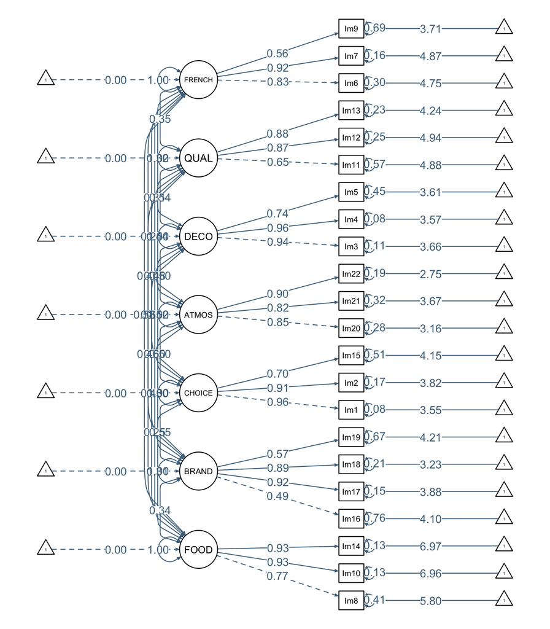

```r
# semPaths(CFA_fit_img, what = "path", whatLabels = "std", style = "mx",
#          rotation = 2, layout = "tree3", mar = c(1, 2, 1, 2),
#          nCharNodes = 7,shapeMan = "rectangle", sizeMan = 8, sizeMan2 = 5,
#          curvePivot=TRUE, edge.label.cex = 1.2, edge.color = "skyblue4")


semPaths(CFA_fit_img, what = "path", whatLabels = "std", style = "mx",
         rotation = 2, layout = "tree3", mar = c(1, 2, 1, 2),
         nCharNodes = 7,shapeMan = "rectangle",
         sizeMan = 4, sizeMan2 = 3, sizeInt = 2, sizeLat = 6, asize = 1.5,
         curvePivot=TRUE, edge.label.cex = .8, edge.color = "skyblue4"
         )
```

```r
lambda = inspect(CFA_fit_img, what="std")$lambda
theta = inspect(CFA_fit_img, what="std")$theta

# create lambda matrix with ones instead of std.all
ones <- lambda
ones[ones>0] <- 1

# a matrix with dimensions of lambda matrix but with lambdas replaced by thetas
theta_lb <- theta %*% ones
```

##### 1.3.1.2.1 Indicator reliability criterion

```r
# calculate indicator reliabilities (should be larger than 0.4)
indicrel <- lambda^2/(lambda^2 + theta_lb)
# indicrel

# replace all values satisfying condition with NaN for visibility
indicrel_fail <- indicrel
indicrel_fail[indicrel_fail>.4] <- NaN
indicrel_fail
```

```
##      FOOD BRAND CHOICE ATMOS DECO QUAL FRENCH
## Im8   NaN   NaN    NaN   NaN  NaN  NaN    NaN
## Im10  NaN   NaN    NaN   NaN  NaN  NaN    NaN
## Im14  NaN   NaN    NaN   NaN  NaN  NaN    NaN
## Im16  NaN 0.235    NaN   NaN  NaN  NaN    NaN
## Im17  NaN   NaN    NaN   NaN  NaN  NaN    NaN
## Im18  NaN   NaN    NaN   NaN  NaN  NaN    NaN
## Im19  NaN 0.326    NaN   NaN  NaN  NaN    NaN
## Im1   NaN   NaN    NaN   NaN  NaN  NaN    NaN
## Im2   NaN   NaN    NaN   NaN  NaN  NaN    NaN
## Im15  NaN   NaN    NaN   NaN  NaN  NaN    NaN
## Im20  NaN   NaN    NaN   NaN  NaN  NaN    NaN
## Im21  NaN   NaN    NaN   NaN  NaN  NaN    NaN
## Im22  NaN   NaN    NaN   NaN  NaN  NaN    NaN
## Im3   NaN   NaN    NaN   NaN  NaN  NaN    NaN
## Im4   NaN   NaN    NaN   NaN  NaN  NaN    NaN
## Im5   NaN   NaN    NaN   NaN  NaN  NaN    NaN
## Im11  NaN   NaN    NaN   NaN  NaN  NaN    NaN
## Im12  NaN   NaN    NaN   NaN  NaN  NaN    NaN
## Im13  NaN   NaN    NaN   NaN  NaN  NaN    NaN
## Im6   NaN   NaN    NaN   NaN  NaN  NaN    NaN
## Im7   NaN   NaN    NaN   NaN  NaN  NaN    NaN
## Im9   NaN   NaN    NaN   NaN  NaN  NaN  0.308
```

##### 1.3.1.2.2 Construct reliability criterion

```r
# calculate construct reliability (should be above .6)
constrrel <- (t(lambda) %*% ones)^2 / ((t(lambda) %*% ones)^2 + t(theta_lb) %*% ones )
# constrrel

# replace all values satisfying condition with NaN for visibility
constrrel_fail <- constrrel
constrrel_fail[constrrel_fail>.6] <- NaN
constrrel_fail
```

```
##        FOOD BRAND CHOICE ATMOS DECO QUAL FRENCH
## FOOD    NaN   NaN    NaN   NaN  NaN  NaN    NaN
## BRAND   NaN   NaN    NaN   NaN  NaN  NaN    NaN
## CHOICE  NaN   NaN    NaN   NaN  NaN  NaN    NaN
## ATMOS   NaN   NaN    NaN   NaN  NaN  NaN    NaN
## DECO    NaN   NaN    NaN   NaN  NaN  NaN    NaN
## QUAL    NaN   NaN    NaN   NaN  NaN  NaN    NaN
## FRENCH  NaN   NaN    NaN   NaN  NaN  NaN    NaN
```

##### 1.3.1.2.3 Average Variance Extracted criterion

```r
# calculate Average Variance Extracted (should be above .5)
AVE <- (t(lambda) %*% lambda) / (t(lambda) %*% lambda + t(theta_lb) %*% ones )
# avgvar

# replace all values satisfying condition with NaN for visibility
AVE_fail <- AVE
AVE_fail[AVE_fail>.5] <- NaN
AVE_fail
```

```
##        FOOD BRAND CHOICE ATMOS DECO QUAL FRENCH
## FOOD    NaN   NaN    NaN   NaN  NaN  NaN    NaN
## BRAND   NaN   NaN    NaN   NaN  NaN  NaN    NaN
## CHOICE  NaN   NaN    NaN   NaN  NaN  NaN    NaN
## ATMOS   NaN   NaN    NaN   NaN  NaN  NaN    NaN
## DECO    NaN   NaN    NaN   NaN  NaN  NaN    NaN
## QUAL    NaN   NaN    NaN   NaN  NaN  NaN    NaN
## FRENCH  NaN   NaN    NaN   NaN  NaN  NaN    NaN
```

##### 1.3.1.2.4 Fornell-Larcker Criteria

```r
# correlations between constructs (factors...) should be lower than .7
psi = inspect(CFA_fit_img, what="std")$psi
psi_fail <- psi
psi_fail[psi_fail<.7] <- NaN
psi_fail
```

```
##        FOOD BRAND CHOICE ATMOS DECO QUAL FRENCH
## FOOD      1
## BRAND   NaN     1
## CHOICE  NaN   NaN      1
## ATMOS   NaN   NaN    NaN     1
## DECO    NaN   NaN    NaN   NaN    1
## QUAL    NaN   NaN    NaN   NaN  NaN    1
## FRENCH  NaN   NaN    NaN   NaN  NaN  NaN      1
```

```r
# AVE should be higher than squared correlations between constructs

# replace diagonal of psi matrix with AVE values
psi2 <- psi - psi * diag(1,nrow(psi),ncol(psi)) + diag(AVE) * diag(1,nrow(AVE),ncol(AVE))

# create matrix with columns filled with AVE
AVE_full <- AVE
AVE_full[is.na(AVE_full)] <- 0 #replace NAs with 0s
AVE_full <- AVE_full^0 %*% AVE_full # multiply a matrix full of ones with AVE_full to get columns filled with AVE

# substract matrices any psi bigger than AVE will be negative
AVEpsi_fail <- AVE_full - psi2
# AVE_full - psi2
AVEpsi_fail[AVEpsi_fail >= 0] <- NaN

AVE_full
```

```
##            FOOD     BRAND    CHOICE     ATMOS      DECO      QUAL    FRENCH
## FOOD   0.776754 0.5517465 0.7481283 0.7385126 0.7848422 0.6492157 0.6164357
## BRAND  0.776754 0.5517465 0.7481283 0.7385126 0.7848422 0.6492157 0.6164357
## CHOICE 0.776754 0.5517465 0.7481283 0.7385126 0.7848422 0.6492157 0.6164357
## ATMOS  0.776754 0.5517465 0.7481283 0.7385126 0.7848422 0.6492157 0.6164357
## DECO   0.776754 0.5517465 0.7481283 0.7385126 0.7848422 0.6492157 0.6164357
## QUAL   0.776754 0.5517465 0.7481283 0.7385126 0.7848422 0.6492157 0.6164357
## FRENCH 0.776754 0.5517465 0.7481283 0.7385126 0.7848422 0.6492157 0.6164357
```

```r
psi
```

```
##         FOOD BRAND CHOICE ATMOS  DECO  QUAL FRENCH
## FOOD   1.000
## BRAND  0.343 1.000
## CHOICE 0.311 0.552  1.000
## ATMOS  0.254 0.502  0.499 1.000
## DECO   0.434 0.604  0.517 0.498 1.000
## QUAL   0.464 0.608  0.485 0.436 0.545 1.000
## FRENCH 0.583 0.396  0.253 0.308 0.325 0.354  1.000
```

```r
AVEpsi_fail
```

```
##          FOOD  BRAND CHOICE  ATMOS   DECO   QUAL FRENCH
## FOOD        .
## BRAND     NaN      .
## CHOICE    NaN -0.001      .
## ATMOS     NaN    NaN    NaN      .
## DECO      NaN -0.052    NaN    NaN      .
## QUAL      NaN -0.057    NaN    NaN    NaN      .
## FRENCH    NaN    NaN    NaN    NaN    NaN    NaN      .
```

#### 1.3.1.3 Modification indices

```r
arrange(modificationindices(CFA_fit_img),-mi)
```

```
##        lhs op  rhs      mi    epc sepc.lv sepc.all sepc.nox
## 1     Im17 ~~ Im18 187.257  1.289   1.289    4.137    4.137
## 2     Im16 ~~ Im19 100.333  0.635   0.635    0.592    0.592
## 3      Im1 ~~  Im2  63.662  0.927   0.927    4.748    4.748
## 4   FRENCH =~  Im8  56.898  0.400   0.409    0.394    0.394
## 5     QUAL =~ Im15  54.204  0.623   0.470    0.387    0.387
## 6     DECO =~ Im19  51.504  0.438   0.554    0.460    0.460
## 7     QUAL =~  Im9  46.154  0.691   0.521    0.384    0.384
## 8    BRAND =~ Im15  45.116  0.736   0.444    0.366    0.366
## 9   CHOICE =~ Im19  43.182  0.371   0.482    0.401    0.401
## 10   BRAND =~  Im9  42.977  0.834   0.503    0.371    0.371
## 11    DECO =~ Im16  37.537  0.407   0.515    0.414    0.414
## 12  CHOICE =~ Im16  35.776  0.368   0.478    0.385    0.385
## 13    Im10 ~~ Im14  33.805  0.236   0.236    2.319    2.319
## 14    FOOD =~ Im19  29.148  0.432   0.346    0.287    0.287
```

[output cut: 349 more lines]

### 1.3.2 Second model

Based on the modification indices we create a new model

```r
CFA_model_img <- "
FOOD =~ Im10 + Im14
BRAND =~ Im17 + Im18
PROF =~ Im16 + Im19
CHOICE =~ Im1 + Im2 + Im15
ATMOS =~ Im20 + Im21 + Im22
DECO =~ Im3 + Im4 + Im5
QUAL =~ Im11 + Im12 + Im13
FRENCH =~ Im6 + Im7 + Im8 + Im9
"

CFA_fit_img <- cfa(CFA_model_img, data=data_EFA, missing="ML")
summary(CFA_fit_img, fit.measures=TRUE, standardized=TRUE)
```

```
## lavaan 0.6.15 ended normally after 65 iterations
##
##   Estimator                                         ML
##   Optimization method                           NLMINB
##   Number of model parameters                        94
##
##   Number of observations                           309
##   Number of missing patterns                         1
##
## Model Test User Model:
##
##   Test statistic                               608.604
##   Degrees of freedom                               181
##   P-value (Chi-square)                           0.000
##
## Model Test Baseline Model:
##
##   Test statistic                              5429.194
##   Degrees of freedom                               231
##   P-value                                        0.000
##
## User Model versus Baseline Model:
##
##   Comparative Fit Index (CFI)                    0.918
##   Tucker-Lewis Index (TLI)                       0.895
##
##   Robust Comparative Fit Index (CFI)             0.918
##   Robust Tucker-Lewis Index (TLI)                0.895
##
## Loglikelihood and Information Criteria:
##
##   Loglikelihood user model (H0)              -8707.473
##   Loglikelihood unrestricted model (H1)      -8403.172
##
##   Akaike (AIC)                               17602.947
##   Bayesian (BIC)                             17953.881
##   Sample-size adjusted Bayesian (SABIC)      17655.750
##
## Root Mean Square Error of Approximation:
##
```

[output cut: 143 more lines]

```
##    .Im11              0.761    0.069   11.008    0.000    0.761    0.573
##    .Im12              0.330    0.048    6.883    0.000    0.330    0.252
##    .Im13              0.365    0.059    6.187    0.000    0.365    0.227
##    .Im6               0.507    0.055    9.207    0.000    0.507    0.339
##    .Im7               0.264    0.047    5.565    0.000    0.264    0.189
##    .Im8               0.507    0.051    9.930    0.000    0.507    0.471
##    .Im9               1.255    0.108   11.622    0.000    1.255    0.683
##     FOOD              0.664    0.065   10.159    0.000    1.000    1.000
##     BRAND             1.481    0.143   10.385    0.000    1.000    1.000
##     PROF              0.917    0.123    7.442    0.000    1.000    1.000
##     CHOICE            1.676    0.151   11.121    0.000    1.000    1.000
##     ATMOS             1.583    0.178    8.901    0.000    1.000    1.000
##     DECO              1.606    0.147   10.925    0.000    1.000    1.000
##     QUAL              0.566    0.093    6.076    0.000    1.000    1.000
##     FRENCH            0.990    0.119    8.306    0.000    1.000    1.000
```

#### 1.3.2.1 Discussion of global fit measures

Chi square: p-value > 0.05

RMSEA RMSEA <= 0.05 Good fit 0.05 < RMSEA <= 0.08 Acceptable fit 0.08 < RMSEA <= 0.10 Bad fit RMSEA > 0.1 Unacceptable fit

CFI CFI < 0.90 definitely reject model 0.90 < CFI < 0.95 high underrejection rates for misspecified models CFI > 0.95 accept model

#### 1.3.2.2 local fit measures

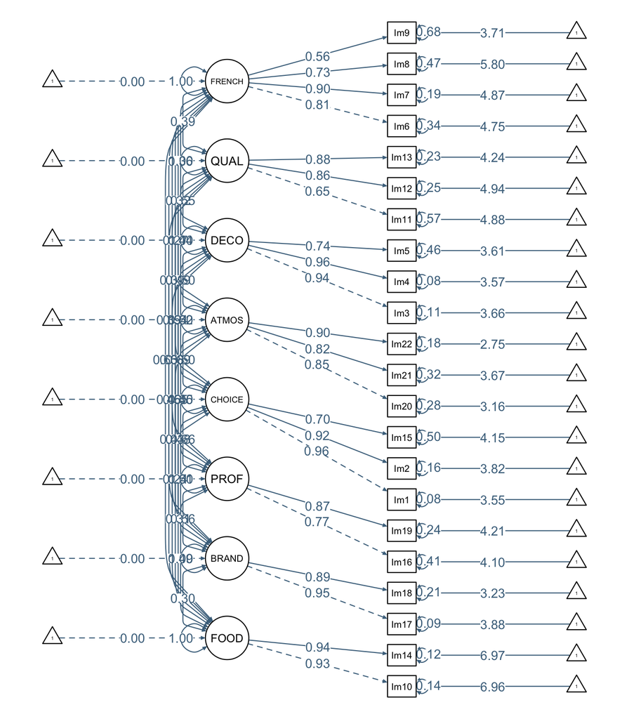

```r
# semPaths(CFA_fit_img, what = "path", whatLabels = "std", style = "mx",
#          rotation = 2, layout = "tree3", mar = c(1, 2, 1, 2),
#          nCharNodes = 7,shapeMan = "rectangle", sizeMan = 8, sizeMan2 = 5,
#          curvePivot=TRUE, edge.label.cex = 1.2, edge.color = "skyblue4")


semPaths(CFA_fit_img, what = "path", whatLabels = "std", style = "mx",
         rotation = 2, layout = "tree3", mar = c(1, 2, 1, 2),
         nCharNodes = 7,shapeMan = "rectangle",
         sizeMan = 4, sizeMan2 = 3, sizeInt = 2, sizeLat = 6, asize = 1.5,
         curvePivot=TRUE, edge.label.cex = .8, edge.color = "skyblue4"
         )
```

```r
lambda = inspect(CFA_fit_img, what="std")$lambda
theta = inspect(CFA_fit_img, what="std")$theta

# create lambda matrix with ones instead of std.all
ones <- lambda
ones[ones>0] <- 1

# a matrix with dimensions of lambda matrix but with lambdas replaced by thetas
theta_lb <- theta %*% ones
```

##### 1.3.2.2.1 Indicator reliability criterion

```r
# calculate indicator reliabilities (should be larger than 0.4)
indicrel <- lambda^2/(lambda^2 + theta_lb)
# indicrel

# replace all values satisfying condition with NaN for visibility
indicrel_fail <- indicrel
indicrel_fail[indicrel_fail>.4] <- NaN
indicrel_fail
```

```
##      FOOD BRAND PROF CHOICE ATMOS DECO QUAL FRENCH
## Im10  NaN   NaN  NaN    NaN   NaN  NaN  NaN    NaN
## Im14  NaN   NaN  NaN    NaN   NaN  NaN  NaN    NaN
## Im17  NaN   NaN  NaN    NaN   NaN  NaN  NaN    NaN
## Im18  NaN   NaN  NaN    NaN   NaN  NaN  NaN    NaN
## Im16  NaN   NaN  NaN    NaN   NaN  NaN  NaN    NaN
## Im19  NaN   NaN  NaN    NaN   NaN  NaN  NaN    NaN
## Im1   NaN   NaN  NaN    NaN   NaN  NaN  NaN    NaN
## Im2   NaN   NaN  NaN    NaN   NaN  NaN  NaN    NaN
## Im15  NaN   NaN  NaN    NaN   NaN  NaN  NaN    NaN
## Im20  NaN   NaN  NaN    NaN   NaN  NaN  NaN    NaN
## Im21  NaN   NaN  NaN    NaN   NaN  NaN  NaN    NaN
## Im22  NaN   NaN  NaN    NaN   NaN  NaN  NaN    NaN
## Im3   NaN   NaN  NaN    NaN   NaN  NaN  NaN    NaN
## Im4   NaN   NaN  NaN    NaN   NaN  NaN  NaN    NaN
## Im5   NaN   NaN  NaN    NaN   NaN  NaN  NaN    NaN
## Im11  NaN   NaN  NaN    NaN   NaN  NaN  NaN    NaN
## Im12  NaN   NaN  NaN    NaN   NaN  NaN  NaN    NaN
## Im13  NaN   NaN  NaN    NaN   NaN  NaN  NaN    NaN
## Im6   NaN   NaN  NaN    NaN   NaN  NaN  NaN    NaN
## Im7   NaN   NaN  NaN    NaN   NaN  NaN  NaN    NaN
## Im8   NaN   NaN  NaN    NaN   NaN  NaN  NaN    NaN
## Im9   NaN   NaN  NaN    NaN   NaN  NaN  NaN  0.317
```

##### 1.3.2.2.2 Construct reliability criterion

```r
# calculate construct reliability (should be above .6)
constrrel <- (t(lambda) %*% ones)^2 / ((t(lambda) %*% ones)^2 + t(theta_lb) %*% ones )
# constrrel

# replace all values satisfying condition with NaN for visibility
constrrel_fail <- constrrel
constrrel_fail[constrrel_fail>.6] <- NaN
constrrel_fail
```

```
##        FOOD BRAND PROF CHOICE ATMOS DECO QUAL FRENCH
## FOOD    NaN   NaN  NaN    NaN   NaN  NaN  NaN    NaN
## BRAND   NaN   NaN  NaN    NaN   NaN  NaN  NaN    NaN
## PROF    NaN   NaN  NaN    NaN   NaN  NaN  NaN    NaN
## CHOICE  NaN   NaN  NaN    NaN   NaN  NaN  NaN    NaN
## ATMOS   NaN   NaN  NaN    NaN   NaN  NaN  NaN    NaN
## DECO    NaN   NaN  NaN    NaN   NaN  NaN  NaN    NaN
## QUAL    NaN   NaN  NaN    NaN   NaN  NaN  NaN    NaN
## FRENCH  NaN   NaN  NaN    NaN   NaN  NaN  NaN    NaN
```

##### 1.3.2.2.3 Average Variance Extracted criterion

```r
# calculate Average Variance Extracted (should be above .5)
AVE <- (t(lambda) %*% lambda) / (t(lambda) %*% lambda + t(theta_lb) %*% ones )
# avgvar

# replace all values satisfying condition with NaN for visibility
AVE_fail <- AVE
AVE_fail[AVE_fail>.5] <- NaN
AVE_fail
```

```
##        FOOD BRAND PROF CHOICE ATMOS DECO QUAL FRENCH
## FOOD    NaN   NaN  NaN    NaN   NaN  NaN  NaN    NaN
## BRAND   NaN   NaN  NaN    NaN   NaN  NaN  NaN    NaN
## PROF    NaN   NaN  NaN    NaN   NaN  NaN  NaN    NaN
## CHOICE  NaN   NaN  NaN    NaN   NaN  NaN  NaN    NaN
## ATMOS   NaN   NaN  NaN    NaN   NaN  NaN  NaN    NaN
## DECO    NaN   NaN  NaN    NaN   NaN  NaN  NaN    NaN
## QUAL    NaN   NaN  NaN    NaN   NaN  NaN  NaN    NaN
## FRENCH  NaN   NaN  NaN    NaN   NaN  NaN  NaN    NaN
```

##### 1.3.2.2.4 Fornell-Larcker Criteria

```r
# correlations between constructs (factors...) should be lower than .7
psi = inspect(CFA_fit_img, what="std")$psi
psi_fail <- psi
psi_fail[psi_fail<.7] <- NaN
psi_fail
```

```
##        FOOD BRAND PROF CHOICE ATMOS DECO QUAL FRENCH
## FOOD      1
## BRAND   NaN     1
## PROF    NaN   NaN    1
## CHOICE  NaN   NaN  NaN      1
## ATMOS   NaN   NaN  NaN    NaN     1
## DECO    NaN   NaN  NaN    NaN   NaN    1
## QUAL    NaN   NaN  NaN    NaN   NaN  NaN    1
## FRENCH  NaN   NaN  NaN    NaN   NaN  NaN  NaN      1
```

```r
# AVE should be higher than squared correlations between constructs

# replace diagonal of psi matrix with AVE values
psi2 <- psi - psi * diag(1,nrow(psi),ncol(psi)) + diag(AVE) * diag(1,nrow(AVE),ncol(AVE))

# create matrix with columns filled with AVE
AVE_full <- AVE
AVE_full[is.na(AVE_full)] <- 0 #replace NAs with 0s
AVE_full <- AVE_full^0 %*% AVE_full # multiply a matrix full of ones with AVE_full to get columns filled with AVE

# substract matrices, replace all values satisfying positive condition (AVE > psi) with NaN
AVEpsi_fail <- AVE_full - psi2
# AVE_full - psi2
AVEpsi_fail[AVEpsi_fail >= 0] <- NaN

AVE_full
```

```
##             FOOD     BRAND      PROF    CHOICE     ATMOS      DECO      QUAL
## FOOD   0.8739488 0.8495203 0.6757057 0.7495833 0.7384314 0.7839582 0.6490007
## BRAND  0.8739488 0.8495203 0.6757057 0.7495833 0.7384314 0.7839582 0.6490007
## PROF   0.8739488 0.8495203 0.6757057 0.7495833 0.7384314 0.7839582 0.6490007
## CHOICE 0.8739488 0.8495203 0.6757057 0.7495833 0.7384314 0.7839582 0.6490007
## ATMOS  0.8739488 0.8495203 0.6757057 0.7495833 0.7384314 0.7839582 0.6490007
## DECO   0.8739488 0.8495203 0.6757057 0.7495833 0.7384314 0.7839582 0.6490007
## QUAL   0.8739488 0.8495203 0.6757057 0.7495833 0.7384314 0.7839582 0.6490007
## FRENCH 0.8739488 0.8495203 0.6757057 0.7495833 0.7384314 0.7839582 0.6490007
##          FRENCH
## FOOD   0.579635
## BRAND  0.579635
## PROF   0.579635
## CHOICE 0.579635
## ATMOS  0.579635
## DECO   0.579635
## QUAL   0.579635
## FRENCH 0.579635
```

```r
psi
```

```
##         FOOD BRAND  PROF CHOICE ATMOS  DECO  QUAL FRENCH
## FOOD   1.000
## BRAND  0.299 1.000
## PROF   0.490 0.564 1.000
## CHOICE 0.312 0.511 0.656  1.000
## ATMOS  0.244 0.477 0.446  0.500 1.000
## DECO   0.431 0.553 0.690  0.520 0.499 1.000
## QUAL   0.460 0.578 0.542  0.486 0.436 0.545 1.000
## FRENCH 0.628 0.385 0.391  0.273 0.325 0.355 0.389  1.000
```

```r
AVEpsi_fail
```

```
##          FOOD  BRAND   PROF CHOICE  ATMOS   DECO   QUAL FRENCH
## FOOD        .
## BRAND     NaN      .
## PROF      NaN    NaN      .
## CHOICE    NaN    NaN    NaN      .
## ATMOS     NaN    NaN    NaN    NaN      .
## DECO      NaN    NaN -0.014    NaN    NaN      .
## QUAL      NaN    NaN    NaN    NaN    NaN    NaN      .
## FRENCH    NaN    NaN    NaN    NaN    NaN    NaN    NaN      .
```

#### 1.3.2.3 Modification indices

```r
arrange(modificationindices(CFA_fit_img),-mi)
```

```
##        lhs op  rhs      mi    epc sepc.lv sepc.all sepc.nox
## 1     FOOD =~  Im8 116.249  0.840   0.684    0.659    0.659
## 2      Im1 ~~  Im2  82.706  0.916   0.916    4.525    4.525
## 3      Im6 ~~  Im7  69.709  0.513   0.513    1.401    1.401
## 4     PROF =~ Im15  59.678  0.637   0.611    0.503    0.503
## 5     QUAL =~ Im15  53.838  0.618   0.465    0.384    0.384
## 6     QUAL =~  Im9  41.013  0.661   0.498    0.367    0.367
## 7    BRAND =~  Im9  39.681  0.388   0.473    0.349    0.349
## 8    BRAND =~ Im15  36.521  0.310   0.378    0.311    0.311
## 9     FOOD =~  Im6  29.089 -0.468  -0.382   -0.312   -0.312
## 10    DECO =~ Im15  26.707  0.253   0.321    0.264    0.264
## 11   ATMOS =~ Im15  24.218  0.247   0.311    0.257    0.257
## 12  FRENCH =~ Im15  22.938  0.270   0.268    0.221    0.221
## 13    Im10 ~~  Im6  22.322 -0.091  -0.091   -0.399   -0.399
## 14    PROF =~  Im8  20.372  0.250   0.240    0.231    0.231
```

[output cut: 368 more lines]

### 1.3.3 Factor scores for path analysis

```r
data_EFA
```

```
##     Im1 Im2 Im3 Im4 Im5 Im6 Im7 Im8 Im9 Im10 Im11 Im12 Im13 Im14 Im15 Im16 Im17
## 7     4   5   6   6   6   7   7   6   7    5    5    6    6    6    4    3    5
## 8     7   7   4   4   4   6   7   6   4    6    5    7    6    6    5    4    3
## 14    6   6   4   4   6   4   4   5   5    4    6    6    6    5    5    4    5
## 17    6   6   6   5   5   7   6   6   6    6    6    6    5    7    5    6    4
## 33    6   6   7   7   6   4   4   6   6    6    5    5    5    6    7    7    6
## 35    6   6   7   7   7   7   7   7   7    7    7    7    7    7    6    7    7
## 38    4   4   4   4   3   6   6   6   5    6    6    6    5    5    6    6    5
## 40    3   3   1   1   5   2   4   7   5    7    3    6    2    5    6    6    1
## 41    4   5   7   7   6   7   7   7   6    7    5    7    7    7    6    6    7
## 45    5   5   4   4   5   6   6   6   6    6    6    4    6    6    4    4    5
## 46    5   5   4   4   1   5   5   5   1    5    1    1    1    5    5    5    1
## 47    5   5   5   5   5   6   6   6   6    6    6    6    6    6    5    5    5
## 48    4   4   4   4   4   6   5   5   5    6    6    6    6    6    6    6    6
## 49    6   6   6   6   5   5   5   6   3    6    6    6    6    6    6    6    6
```

[output cut: 605 more lines]

```r
data.frame(EFA_PCn[[3]]$scores)
```

```
##              RC2          RC1         RC3           RC6         RC4
## 7   -1.613872304 -0.404515699 -1.86372652  1.6739483600  0.53516807
## 8   -0.116052003  2.085336303  0.21577814 -1.0745339165  0.44353426
## 14  -2.229177512  0.936919150  0.84824908 -0.0803429154  1.09304729
## 17   0.245607868  0.915621167 -0.22802092  0.3451077408 -0.02098399
## 33   0.191020021  0.972858593  0.73922091  1.2554295013 -1.07536591
## 35   0.662851924  0.508375215 -1.90263405  1.3924412022  0.90085409
## 38   0.037639094 -0.326372978  0.50110577 -1.5101486135  0.08990527
## 40   1.746171435  0.078155853 -1.23772672 -1.9446200147 -0.62867162
## 41   0.680818905 -0.856159466 -0.23252954  1.0436669777  0.18101205
## 45  -0.616672555 -0.153214737  0.72785835 -0.3248421413  0.06210685
## 46   0.410678492  1.603326250  0.64201647 -0.9631334807 -5.03549951
## 47  -0.378685020 -0.014993466  0.13306787  0.0080289295  0.53483645
## 48   0.008755514 -0.327587489 -0.84233701 -1.0877122368  0.49117684
## 49   0.164371792  1.241551486 -2.16450107  0.6096633346  0.19951664
```

[output cut: 605 more lines]

```r
CFA_data = cbind(data_EFA, EFA_PCn[[3]]$scores, survey["SAT_1"])
CFA_data
```

```
##     Im1 Im2 Im3 Im4 Im5 Im6 Im7 Im8 Im9 Im10 Im11 Im12 Im13 Im14 Im15 Im16 Im17
## 7     4   5   6   6   6   7   7   6   7    5    5    6    6    6    4    3    5
## 8     7   7   4   4   4   6   7   6   4    6    5    7    6    6    5    4    3
## 14    6   6   4   4   6   4   4   5   5    4    6    6    6    5    5    4    5
## 17    6   6   6   5   5   7   6   6   6    6    6    6    5    7    5    6    4
## 33    6   6   7   7   6   4   4   6   6    6    5    5    5    6    7    7    6
## 35    6   6   7   7   7   7   7   7   7    7    7    7    7    7    6    7    7
## 38    4   4   4   4   3   6   6   6   5    6    6    6    5    5    6    6    5
## 40    3   3   1   1   5   2   4   7   5    7    3    6    2    5    6    6    1
## 41    4   5   7   7   6   7   7   7   6    7    5    7    7    7    6    6    7
## 45    5   5   4   4   5   6   6   6   6    6    6    4    6    6    4    4    5
## 46    5   5   4   4   1   5   5   5   1    5    1    1    1    5    5    5    1
## 47    5   5   5   5   5   6   6   6   6    6    6    6    6    6    5    5    5
## 48    4   4   4   4   4   6   5   5   5    6    6    6    6    6    6    6    6
## 49    6   6   6   6   5   5   5   6   3    6    6    6    6    6    6    6    6
```

[output cut: 915 more lines]

```r
# colnames(CFA_data)[23:29] = c("Gourmet food", "Brand image", "Choice range", "Relaxed atmosphere", "Decoration", "Product quality", "Frenchness")

# colnames(CFA_data)[23:27] = c("FOOD", "BRAND", "CHOICE", "ATMOS", "DECO")
colnames(CFA_data)[23:29] = c("FOOD", "BRAND", "CHOICE", "ATMOS", "DECO", "QUAL", "FRENCH")

CFA_data
```

```
##     Im1 Im2 Im3 Im4 Im5 Im6 Im7 Im8 Im9 Im10 Im11 Im12 Im13 Im14 Im15 Im16 Im17
## 7     4   5   6   6   6   7   7   6   7    5    5    6    6    6    4    3    5
## 8     7   7   4   4   4   6   7   6   4    6    5    7    6    6    5    4    3
## 14    6   6   4   4   6   4   4   5   5    4    6    6    6    5    5    4    5
## 17    6   6   6   5   5   7   6   6   6    6    6    6    5    7    5    6    4
## 33    6   6   7   7   6   4   4   6   6    6    5    5    5    6    7    7    6
## 35    6   6   7   7   7   7   7   7   7    7    7    7    7    7    6    7    7
## 38    4   4   4   4   3   6   6   6   5    6    6    6    5    5    6    6    5
## 40    3   3   1   1   5   2   4   7   5    7    3    6    2    5    6    6    1
## 41    4   5   7   7   6   7   7   7   6    7    5    7    7    7    6    6    7
## 45    5   5   4   4   5   6   6   6   6    6    6    4    6    6    4    4    5
## 46    5   5   4   4   1   5   5   5   1    5    1    1    1    5    5    5    1
## 47    5   5   5   5   5   6   6   6   6    6    6    6    6    6    5    5    5
## 48    4   4   4   4   4   6   5   5   5    6    6    6    6    6    6    6    6
## 49    6   6   6   6   5   5   5   6   3    6    6    6    6    6    6    6    6
```

[output cut: 915 more lines]

### 1.3.4 model

```r
# model_SAT_1 <-"
# SAT_1 ~ Im1 + Im2 + Im3 + Im4 + Im5 + Im6 + Im7 + Im8 + Im9 + Im10 + Im11 + Im12 + Im13 + Im14 + Im15 + Im16 + Im17 + Im18 + Im19 + Im20 + Im21 + Im22
# "

model_SAT_1 <-"
SAT_1 ~ FOOD + BRAND + CHOICE + ATMOS + DECO + QUAL + FRENCH
"

# model_SAT_1 <-"SAT_1 ~ ."
```

### 1.3.5 linear regression

```r
# linear regression
lm_SAT_1 <-  lm (model_SAT_1, data = CFA_data)
summary(lm_SAT_1)
```

```
##
## Call:
## lm(formula = model_SAT_1, data = CFA_data)
##
## Residuals:
##     Min      1Q  Median      3Q     Max
## -3.1922 -0.4958  0.1006  0.5868  2.2802
##
## Coefficients:
##             Estimate Std. Error t value Pr(>|t|)
## (Intercept)  5.30097    0.04936 107.391  < 2e-16 ***
## FOOD         0.23921    0.04944   4.838 2.09e-06 ***
## BRAND        0.34238    0.04944   6.925 2.64e-11 ***
## CHOICE       0.19921    0.04944   4.029 7.09e-05 ***
## ATMOS        0.08092    0.04944   1.637 0.102761
## DECO         0.09602    0.04944   1.942 0.053047 .
## QUAL         0.09427    0.04944   1.907 0.057519 .
## FRENCH       0.18764    0.04944   3.795 0.000178 ***
## ---
## Signif. codes:  0 '***' 0.001 '**' 0.01 '*' 0.05 '.' 0.1 ' ' 1
##
## Residual standard error: 0.8677 on 301 degrees of freedom
## Multiple R-squared:  0.2713, Adjusted R-squared:  0.2544
## F-statistic: 16.01 on 7 and 301 DF,  p-value: < 2.2e-16
```

```r
# note: lm deletes all missing variables in the Xs! (not in Ys) (see help lavOptions)
```

### 1.3.6 path analysis

```r
# path analysis
cfa_SAT_1 <- cfa(model_SAT_1, data=CFA_data, missing="ML")
summary(cfa_SAT_1, fit.measures=TRUE, standardized=TRUE)
```

```
## lavaan 0.6.15 ended normally after 1 iteration
##
##   Estimator                                         ML
##   Optimization method                           NLMINB
##   Number of model parameters                         9
##
##   Number of observations                           309
##   Number of missing patterns                         1
##
## Model Test User Model:
##
##   Test statistic                                 0.000
##   Degrees of freedom                                 0
##
## Model Test Baseline Model:
##
##   Test statistic                                97.814
##   Degrees of freedom                                 7
##   P-value                                        0.000
##
## User Model versus Baseline Model:
##
##   Comparative Fit Index (CFI)                    1.000
##   Tucker-Lewis Index (TLI)                       1.000
##
##   Robust Comparative Fit Index (CFI)             1.000
##   Robust Tucker-Lewis Index (TLI)                1.000
##
## Loglikelihood and Information Criteria:
##
##   Loglikelihood user model (H0)               -390.546
##   Loglikelihood unrestricted model (H1)       -390.546
##
##   Akaike (AIC)                                 799.093
##   Bayesian (BIC)                               832.693
##   Sample-size adjusted Bayesian (SABIC)        804.148
##
## Root Mean Square Error of Approximation:
##
##   RMSEA                                          0.000
```

[output cut: 24 more lines]

```
##     FOOD              0.239    0.049    4.902    0.000    0.239    0.238
##     BRAND             0.342    0.049    7.016    0.000    0.342    0.341
##     CHOICE            0.199    0.049    4.082    0.000    0.199    0.198
##     ATMOS             0.081    0.049    1.658    0.097    0.081    0.081
##     DECO              0.096    0.049    1.968    0.049    0.096    0.096
##     QUAL              0.094    0.049    1.932    0.053    0.094    0.094
##     FRENCH            0.188    0.049    3.845    0.000    0.188    0.187
##
## Intercepts:
##                    Estimate  Std.Err  z-value  P(>|z|)   Std.lv  Std.all
##    .SAT_1             5.301    0.049  108.809    0.000    5.301    5.284
##
## Variances:
##                    Estimate  Std.Err  z-value  P(>|z|)   Std.lv  Std.all
##    .SAT_1             0.733    0.059   12.430    0.000    0.733    0.729
```

```r
# note: cfa deletes all missing variables in the Xs! (not in Ys) (see help lavOptions)
```